# MTH6139 Time Series

Coursework 1

Jay Jhamt

Spring term 2025

# Introduction

A time series is a sequence of data points recorded at regular time intervals. Time series analysis is used across a wide variety of fields and industries to understand patterns in data over time and make predictions about the future.

In R, time series data is stored as a ts object which keeps track of both the values and the time they were recorded. A time series consists of its trend, seasonality, holidays and noise.

The trend is the long term direction of the data, it shows whether the data is generally increasing, decreasing or staying the same.

The seasonality/seasonal component refers to repeating patterns that occur at regular intervals. An example of this is retail sales, sales tend to spike during the December Christmas period then plummet in January making them a seasonal component.

Holidays are known, irregular events that cause predictable but non-periodic spikes or dips in data.

Noise (or residuals) is the random variation in the data that cannot be explained by the trend or seasonality, it is entirely unpredictable.

# What is Prophet?

Prophet is a forecasting tool developed and released by Meta in 2017. It is available in both R and Python and is designed to make forecasting time series data accessible and easy to use for a variety of audiences, such as business owners or data scientists and analysts.

According to Meta’s official Prophet documentation (Meta Research, 2017), Prophet was designed to produce reliable forecasts to help with planning and goal setting. It has been used within Meta itself, which further demonstrates its reliability and effectiveness as a forecasting tool.

Again as outlined by Randula (2024), Prophet works by breaking down a time series into its four key components, mentioned in the introduction, modelling each one individually before combining them to produce a final forecast.

# Project Objectives

Our objectives for this project are:

- Explore the co2 dataset and understand its structure and properties.
- Convert the data into a format suitable for Prophet and build a forecasting model.
- Visualise the forecast and analyse the predicted trend in CO2 levels beyond 1997.
- Understand the components of the forecast, including the trend and seasonal patterns throughout the year.
- Analyse the results and evaluate whether the forecast looks realistic.
- Apply Prophet to a second dataset (monthly car sales) to show its versatility across different types of time series data.
- Directly compare the two datasets over the same timeframe, analysing differences in trend, seasonality and forecast uncertainty.

# Section 1: CO2 Dataset

## 1.1: Introducing the co2 dataset

We will first use Meta’s Prophet forecasting system to forecast atmospheric CO2 levels. The co2 dataset is a built-in R dataset that measures atmospheric CO2 concentrations in parts per million (ppm), recorded monthly from 1959 to 1997 at the Mauna Loa Observatory in Hawaii, we prove this below.

```r
library(prophet)

# Look at the co2 dataset
start(co2)
```

```
## [1] 1959    1
```

```r
end(co2)
```

```
## [1] 1997   12
```

```r
frequency(co2)
```

```
## [1] 12
```

The co2 dataset starts in 1959 and ends in 1997 with a frequency of 12, confirming it is measured monthly.

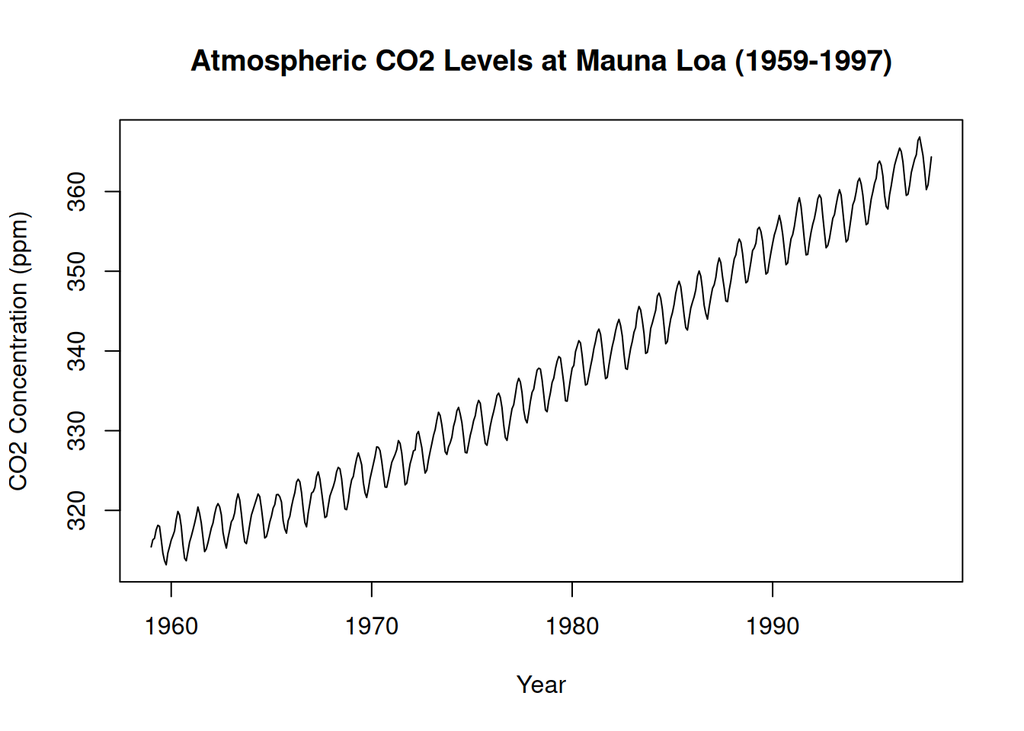

```r
plot(co2,
     main="Atmospheric CO2 Levels at Mauna Loa (1959-1997)",
     xlab="Year",
     ylab="CO2 Concentration (ppm)")
```

Here, we have our raw data from the co2 data provided. The plot shows a clear upward trend in CO2 levels from around 315 ppm in 1959 to around 365 ppm in 1997. There is also a visible seasonal pattern where CO2 levels rise and fall repeatedly each year, creating a wave-like appearance on the graph.

Additionally, we can implement the summary of our linear model (formed from the co2 data) and find out the trend from there.

```r
# Create a time variable
time_index = time(co2)

# Run a linear regression
LinearModel = lm(co2 ~ time_index)

# Show the results
summary(LinearModel)
```

```
##
## Call:
## lm(formula = co2 ~ time_index)
##
## Residuals:
##     Min      1Q  Median      3Q     Max
## -6.0399 -1.9476 -0.0017  1.9113  6.5149
##
## Coefficients:
##               Estimate Std. Error t value Pr(>|t|)
## (Intercept) -2.250e+03  2.127e+01  -105.8   <2e-16 ***
## time_index   1.308e+00  1.075e-02   121.6   <2e-16 ***
## ---
## Signif. codes:  0 '***' 0.001 '**' 0.01 '*' 0.05 '.' 0.1 ' ' 1
##
## Residual standard error: 2.618 on 466 degrees of freedom
## Multiple R-squared:  0.9695, Adjusted R-squared:  0.9694
## F-statistic: 1.479e+04 on 1 and 466 DF,  p-value: < 2.2e-16
```

- time(co2) changes time values from the co2 ts object as numbers, for example 1959.000, 1959.083, 1959.167, etc representing each month.

The summary shows us the slope of the trend line, we can see this from the “time_index” part which tells us how much CO2 levels are increasing on average per year. We can see it is 1.307, as it is positive the line will go upwards. As mentioned, it means CO2 levels are increasing approximately 1.307 ppm every year on average.

We can also take a look at the “Multiple R-squared” figure, this tells us the R-squared value is 0.97 confirming that this upward trend is very strong, explaining 97% of the variation in the data.

In general, we can use the summary to essentially view the mathematical part of how Prophet models each component of a time series.

## 1.2: Converting the data for Prophet

Prophet requires the data to be in a dataframe with a column called ds for dates and a column called y for values. We need to convert the co2 ts object into this format.

```r
d = data.frame(
  ds = zoo::as.Date(time(co2)),
  y = as.numeric(co2)
)
head(d)
```

```
##           ds      y
## 1 1959-01-01 315.42
## 2 1959-02-01 316.31
## 3 1959-03-01 316.50
## 4 1959-04-01 317.56
## 5 1959-05-01 318.13
## 6 1959-06-01 318.00
```

- data.frame() creates a table with columns
- zoo::as.Date() uses the zoo library to convert the values into a date that Prophet can understand
- The head() function shows us the first few rows of our dataframe to confirm it has been set up correctly.

## 1.3: Forecasting with Prophet, Visualising the data

We now fit the Prophet model to our data and forecast 40 periods ahead (10 years into the future beyond 1997).

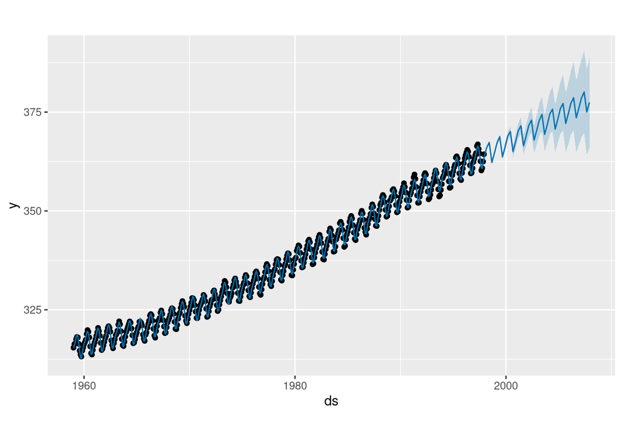

```r
ProphetModel = prophet(d)
FutureDates = make_future_dataframe(ProphetModel, 40, freq = "quarter")
Forecast = predict(ProphetModel, FutureDates)
plot(ProphetModel, Forecast)
```

The plot shows the forecast for CO2 levels. The black dots represent the actual data, the blue line shows the predicted trend and the shaded area shows the uncertainty interval.

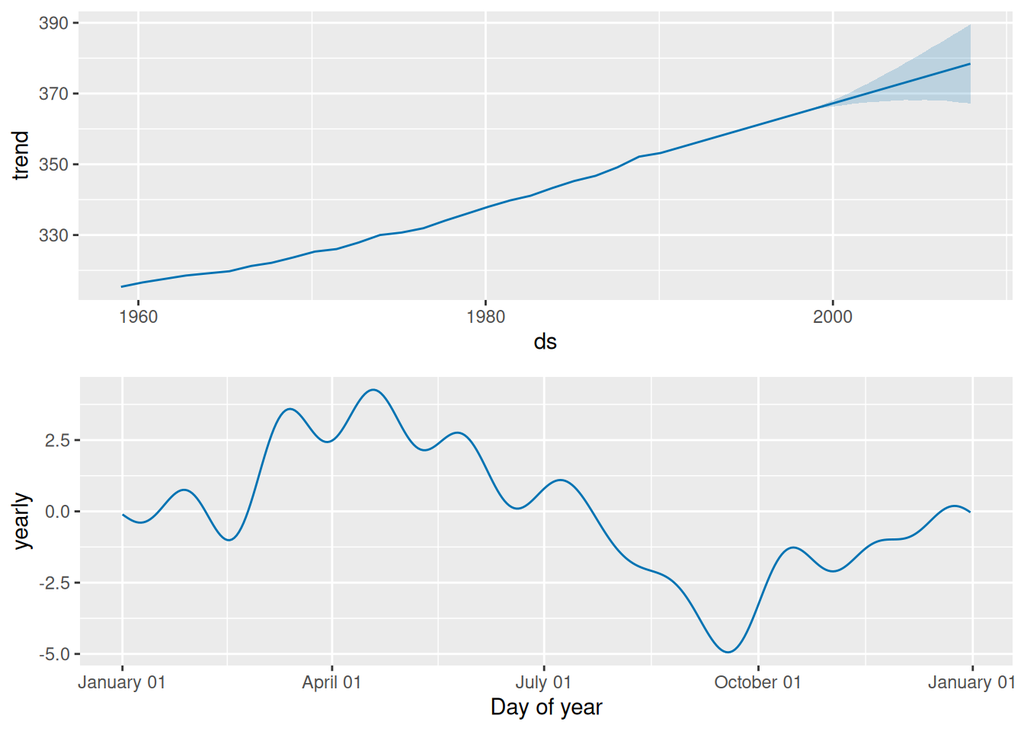

```r
prophet_plot_components(ProphetModel, Forecast)
```

The components plot breaks down the forecast into its individual parts.

The yearly seasonality plot shows that CO2 levels tend to hit their peak around May and reach their lowest point around September each year. This is due to the fact its summer, so plants absorb more CO2 through photosynthesis. Whereas in the winter, plant activity slows and CO2 levels rise again.

In this project we do not include any holiday effects as the co2 dataset is a natural atmospheric measurement and is not affected by special events or irregular occurrences.

# Section 2: Car Sales Forecast

## 2.1: Introducing a new dataset, monthly car sales

In this section we apply Prophet to a different time series dataset to demonstrate how the tool can be used across different domains. We use a monthly car sales dataset sourced from Machine Learning Mastery (Brownlee, J.) to forecast future car sales.

```r
# Dataset sourced from Brownlee, J. Machine Learning Mastery
# Available at: https://raw.githubusercontent.com/jbrownlee/
# Datasets/master/monthly-car-sales.csv

CarSales = read.csv(paste0(
  "https://raw.githubusercontent.com/jbrownlee/",
  "Datasets/master/monthly-car-sales.csv"
))
head(CarSales)
```

```
##     Month Sales
## 1 1960-01  6550
## 2 1960-02  8728
## 3 1960-03 12026
## 4 1960-04 14395
## 5 1960-05 14587
## 6 1960-06 13791
```

The head() function shows us the first few rows of the dataset. We can see it has two columns, one for the date and one for the number of cars sold. Before we can use Prophet we need to rename these columns to ds and y as Prophet requires.

## 2.2: Preparing the Dataset

Just like with the co2 dataset, we need to convert the car sales data into a format that Prophet can work with. This means renaming the columns to ds and y and converting the date column into a proper date format.

```r
# Rename columns for Prophet
colnames(CarSales) = c("ds", "y")

# Convert ds to date format
CarSales$ds = as.Date(paste0(CarSales$ds, "-01"),
                      format = "%Y-%m-%d")
head(CarSales)
```

```
##           ds     y
## 1 1960-01-01  6550
## 2 1960-02-01  8728
## 3 1960-03-01 12026
## 4 1960-04-01 14395
## 5 1960-05-01 14587
## 6 1960-06-01 13791
```

The dataset now has the correct format for Prophet with a ds column containing the dates and a y column containing the number of cars sold each month. The as.Date() function converts the date column into a proper date format that Prophet can understand.

## 2.3: Visualising the Raw Data

Before running Prophet we should visualise the raw data to understand its structure and identify any trends or seasonal patterns.

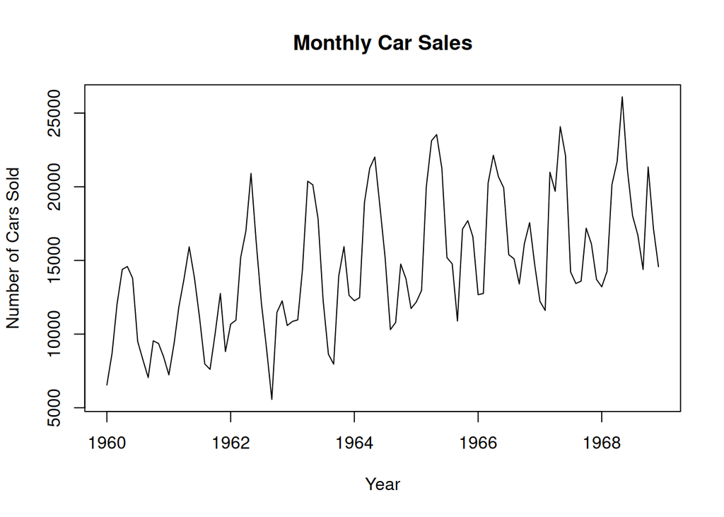

```r
plot(CarSales$ds, CarSales$y,
     type = "l",
     main = "Monthly Car Sales",
     xlab = "Year",
     ylab = "Number of Cars Sold")
```

This plot shows the raw car sales data over time. We can see there is a general upward trend in car sales over the period, with a clear seasonal pattern repeating each year.

## 2.4: Forecasting with Prophet

We now fit the Prophet model to the car sales data and forecast 72 months ahead. Prophet will automatically detect the trend and seasonality in the data and use these to make predictions about future car sales.

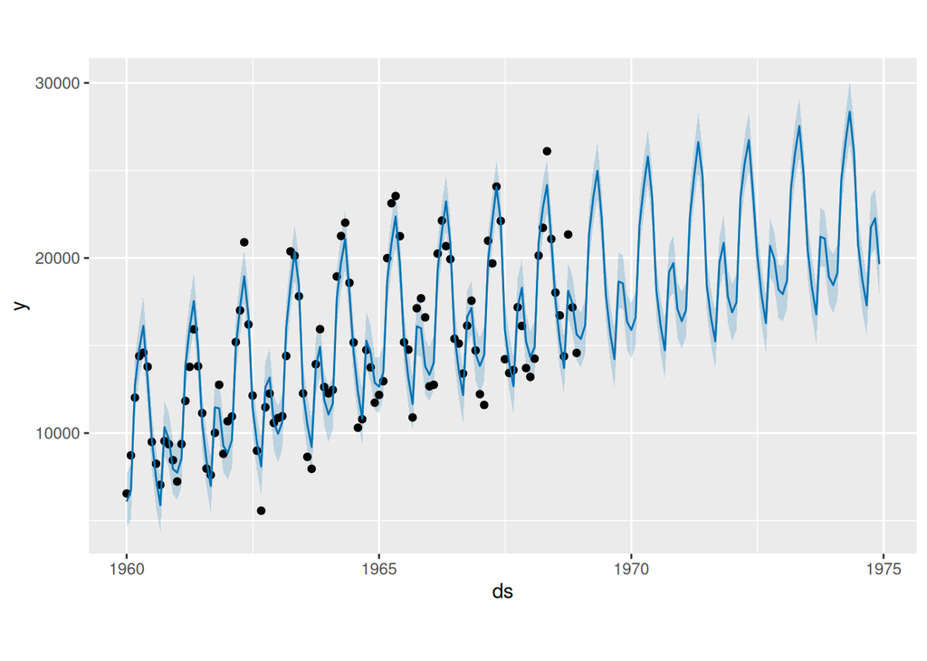

```r
CarModel = prophet(CarSales)
CarFuture = make_future_dataframe(CarModel, 72,
                                  freq = "month")
CarForecast = predict(CarModel, CarFuture)
plot(CarModel, CarForecast)
```

## 2.5: Components of the Forecast

Just like with the co2 dataset, we can use the prophet_plot_components() function to break down the forecast into its individual components and better understand what Prophet has detected in the data.

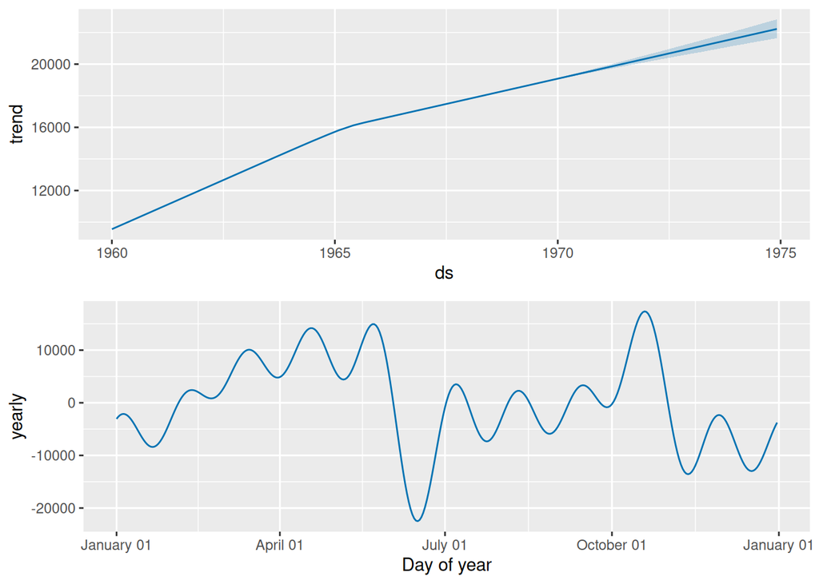

```r
prophet_plot_components(CarModel, CarForecast)
```

The components plot breaks down the car sales forecast into its individual parts.

The trend plot shows the overall direction of car sales over time. We can see whether sales have been generally increasing or decreasing over the period.

The yearly seasonality plot shows how car sales vary throughout the year. This is particularly interesting for car sales as we might expect lower sales at certain times of year, such as when people go on holidays in the summer.

# Section 3: Comparing CO2 and Car Sales Forecasts

## 3.1 Introduction & Subsetting the data

```r
library(prophet)
library(ggplot2)
# Subset co2 data to only include up to 1970
CO2Subset = d[d$ds <= as.Date("1970-01-01"), ]

# Subset car sales data to match the same timeframe
CarSubset = CarSales[CarSales$ds <= as.Date("1970-01-01"), ]

# Run Prophet on subsetted CO2 data
CO2SubsetModel = prophet(CO2Subset)
CO2SubsetFuture = make_future_dataframe(CO2SubsetModel,
                                        40,
                                        freq = "quarter")
CO2SubsetForecast = predict(CO2SubsetModel,
                            CO2SubsetFuture)

# Run Prophet on subsetted Car Sales data
CarSubsetModel = prophet(CarSubset)
CarSubsetFuture = make_future_dataframe(CarSubsetModel,
                                        24,
                                        freq = "month")
CarSubsetForecast = predict(CarSubsetModel,
                            CarSubsetFuture)
```

## 3.2 Comparing the Raw Data

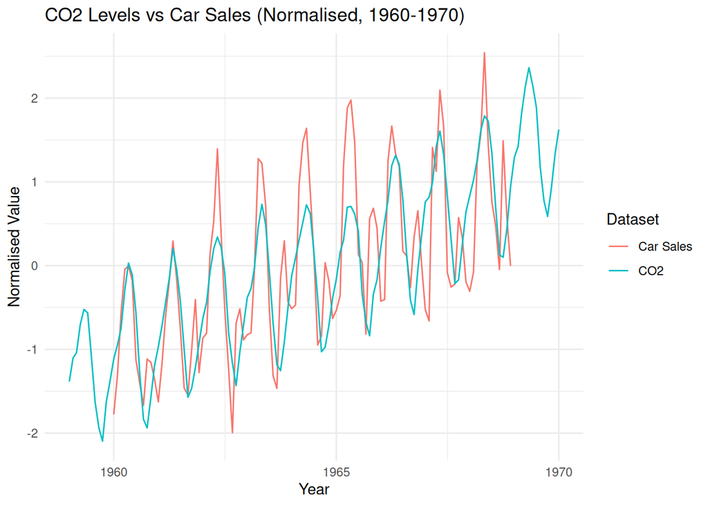

```r
# Normalise both datasets to the same scale
CO2Normalised = data.frame(
  ds = CO2Subset$ds,
  y = scale(CO2Subset$y),
  Dataset = "CO2"
)

CarNormalised = data.frame(
  ds = CarSubset$ds,
  y = scale(CarSubset$y),
  Dataset = "Car Sales"
)

# Combine both datasets
Combined = rbind(CO2Normalised, CarNormalised)

# Plot both on the same graph
ggplot(Combined, aes(x = ds, y = y, colour = Dataset)) +
  geom_line() +
  ggtitle("CO2 Levels vs Car Sales (Normalised, 1960-1970)") +
  xlab("Year") +
  ylab("Normalised Value") +
  theme_minimal()
```

The plot above shows both datasets normalised to the same scale so we can compare them directly. Normalising the data means we subtract the mean and divide by the standard deviation, allowing us to compare datasets that have different units and scales.

We can already see some key differences between the two datasets. The CO2 data shows a very smooth and consistent upward trend with regular seasonal fluctuations, while the car sales data shows a more irregular pattern with larger and more unpredictable fluctuations.

## 3.3 Comparing the Trend

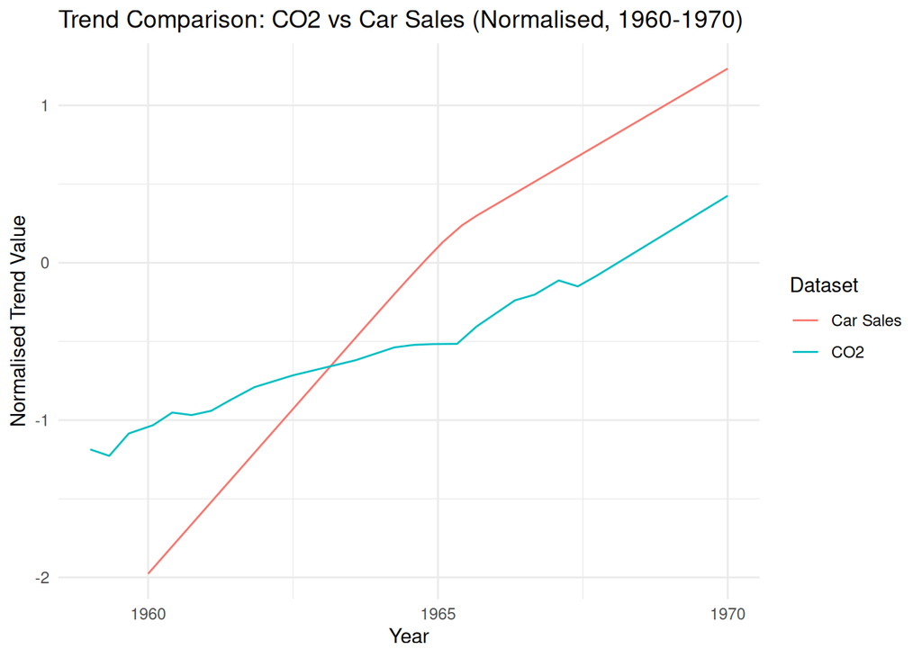

```r
# Extract and normalise trend from both forecasts
# Filter to only show up to 1970
CO2Trend = data.frame(
  ds = CO2SubsetForecast$ds,
  trend = scale(CO2SubsetForecast$trend),
  Dataset = "CO2"
)
CO2Trend = CO2Trend[CO2Trend$ds <= as.Date("1970-01-01"), ]

CarTrend = data.frame(
  ds = CarSubsetForecast$ds,
  trend = scale(CarSubsetForecast$trend),
  Dataset = "Car Sales"
)
CarTrend = CarTrend[CarTrend$ds <= as.Date("1970-01-01"), ]

# Combine trends
CombinedTrend = rbind(CO2Trend, CarTrend)

# Plot both trends
ggplot(CombinedTrend, aes(x = ds,
                           y = trend,
                           colour = Dataset)) +
  geom_line() +
  ggtitle("Trend Comparison: CO2 vs Car Sales (Normalised, 1960-1970)") +
  xlab("Year") +
  ylab("Normalised Trend Value") +
  theme_minimal()
```

- CO2SubsetForecast$trend: extracts the trend values from the CO2 forecast
- scale(): normalises the trend values so they can be compared with car sales which are on a completely different scale
- CO2Trend = CO2Trend[CO2Trend$ds <= as.Date(“1970-01-01”), ]: Filters the CO2Trend dataframe to only keep rows where the date is on or before 1970
- rbind(): stands for row bind, it stacks two dataframes on top of each other
- aes(): stands for aesthetics, defines how the data maps to the plot
- geom_line(): Draws the data as lines rather than dots or bars

The trend comparison plot shows how the overall direction of both datasets compares over the same timeframe from 1960 to 1970. Both trends have been normalised to the same scale so they can be compared directly.

Both datasets show an overall upward trend during this period, but the rate and consistency of growth differs significantly between them.

## 3.4 Comparing the Seasonality

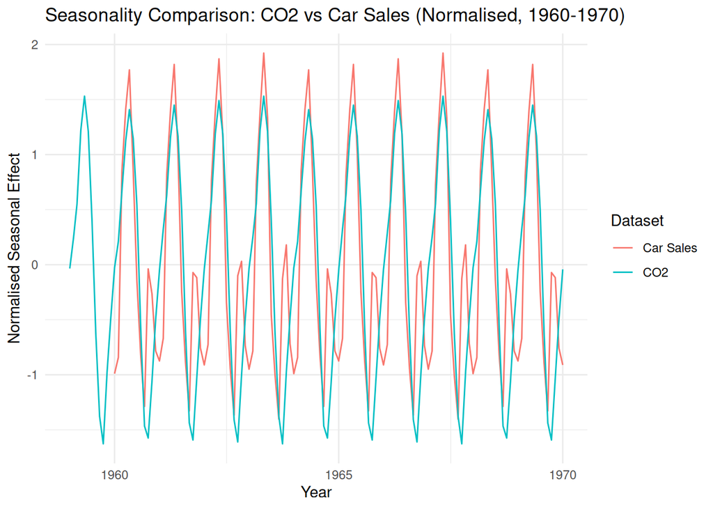

```r
# Extract and normalise seasonality from both forecasts
# Filter to only show up to 1970
CO2Seasonality = data.frame(
  ds = CO2SubsetForecast$ds,
  yearly = scale(CO2SubsetForecast$yearly),
  Dataset = "CO2"
)
CO2Seasonality = CO2Seasonality[CO2Seasonality$ds <= as.Date("1970-01-01"), ]

CarSeasonality = data.frame(
  ds = CarSubsetForecast$ds,
  yearly = scale(CarSubsetForecast$yearly),
  Dataset = "Car Sales"
)
CarSeasonality = CarSeasonality[CarSeasonality$ds <= as.Date("1970-01-01"), ]

# Combine seasonality
CombinedSeasonality = rbind(CO2Seasonality,
                             CarSeasonality)

# Plot both seasonalities
ggplot(CombinedSeasonality, aes(x = ds,
                                 y = yearly,
                                 colour = Dataset)) +
  geom_line() +
  ggtitle("Seasonality Comparison: CO2 vs Car Sales (Normalised, 1960-1970)") +
  xlab("Year") +
  ylab("Normalised Seasonal Effect") +
  theme_minimal()
```

The seasonality comparison plot shows the repeating seasonal patterns in both datasets over the same timeframe.

The CO2 seasonality shows a very regular and consistent wave pattern that repeats every year. CO2 levels peak around May and reach their lowest point around September each year due to plant photosynthesis activity during summer months.

## 3.5 Comparing the Forecast Uncertainty

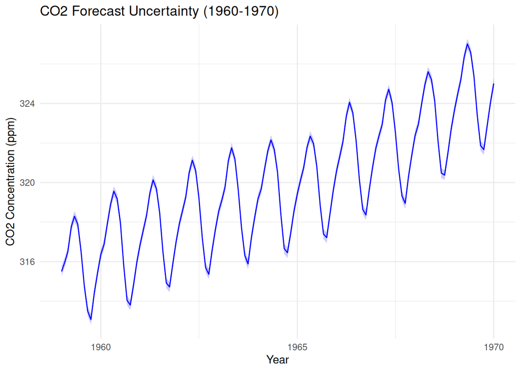

```r
# Filter CO2 forecast to only show up to 1970
CO2UncertaintyFiltered = CO2SubsetForecast[
  CO2SubsetForecast$ds <= as.Date("1970-01-01"), ]

# Filter Car Sales forecast to only show up to 1970
CarUncertaintyFiltered = CarSubsetForecast[
  CarSubsetForecast$ds <= as.Date("1970-01-01"), ]

# Plot CO2 uncertainty
ggplot(CO2UncertaintyFiltered, aes(x = ds)) +
  geom_ribbon(aes(ymin = yhat_lower,
                  ymax = yhat_upper),
              fill = "blue", alpha = 0.2) +
  geom_line(aes(y = yhat), colour = "blue") +
  ggtitle("CO2 Forecast Uncertainty (1960-1970)") +
  xlab("Year") +
  ylab("CO2 Concentration (ppm)") +
  theme_minimal()
```

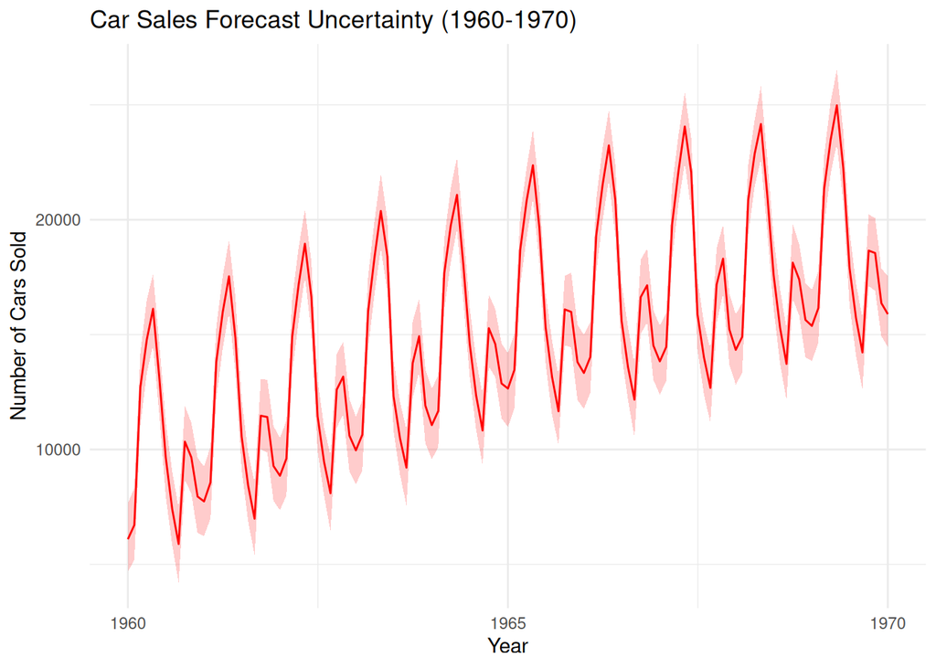

```r
# Plot Car Sales uncertainty
ggplot(CarUncertaintyFiltered, aes(x = ds)) +
  geom_ribbon(aes(ymin = yhat_lower,
                  ymax = yhat_upper),
              fill = "red", alpha = 0.2) +
  geom_line(aes(y = yhat), colour = "red") +
  ggtitle("Car Sales Forecast Uncertainty (1960-1970)") +
  xlab("Year") +
  ylab("Number of Cars Sold") +
  theme_minimal()
```

The uncertainty plots show how confident Prophet is in its predictions for each dataset over the same timeframe.

The CO2 forecast shows a relatively narrow uncertainty interval, meaning Prophet is quite confident in its predictions. This is because CO2 levels follow a very consistent and predictable pattern with a strong linear trend and regular seasonality.

The car sales forecast shows a wider uncertainty interval, meaning Prophet is less confident in its predictions. This reflects the more irregular and unpredictable nature of car sales data which is influenced by many external factors that are difficult to forecast.

## 3.6 Summary of Comparison

In summary, comparing the two datasets over the same timeframe from 1960 to 1970 reveals some interesting differences in how Prophet handles different types of time series data:

- The CO2 dataset has a stronger and more consistent trend making it easier for Prophet to forecast accurately with a narrow uncertainty interval
- The car sales dataset has a more complex and irregular pattern resulting in a wider uncertainty interval and less confident predictions
- Both datasets show clear yearly seasonality but the nature of the seasonal patterns is different, reflecting the different underlying processes driving each dataset
- Prophet handles both datasets effectively demonstrating its versatility as a forecasting tool across different domains

# Section 4: Conclusion

When comparing the two datasets over the same timeframe from 1960 to 1970, we found that the CO2 dataset had a stronger and more consistent trend making it easier for Prophet to forecast accurately, while the car sales dataset showed more irregular patterns resulting in less confident predictions.

Overall this project has demonstrated that Prophet is a powerful and versatile forecasting tool that can be applied effectively to different types of time series data.

# References

- Taylor, S.J. and Letham, B. (2018). Forecasting at scale. The American Statistician, 72(1), pp.37-45. Available at: https://facebook.github.io/prophet/
- Meta Research (2017). Prophet: Forecasting at Scale. Available at: https://facebook.github.io/prophet/
- GeeksforGeeks (2024). Time Series Analysis using Facebook Prophet. Available at: https://www.geeksforgeeks.org/data-science/time-series-analysis-using-facebook-prophet/
- Randula, D. (2024). Prophet by Meta: A Powerful Tool for Time Series Forecasting. Available at: https://medium.com/@dinethrandula2001
- R Documentation. co2: Mauna Loa Atmospheric CO2 Concentration. Available at: https://stat.ethz.ch/R-manual/R-devel/library/datasets/html/co2.html
- Brownlee, J. Machine Learning Mastery. Monthly Car Sales Dataset. Available at: https://raw.githubusercontent.com/jbrownlee/Datasets/master/monthly-car-sales.csv